# 11-tcell-composition-analysis

Bicna Song

2026-09-21

## Setup

This block loads packages and defines module paths for the T cell composition analysis.

```r
suppressPackageStartupMessages({
  library(rprojroot)
  library(dplyr)
  library(tibble)
  library(Seurat)
  library(ggplot2)
  library(sccomp)
})

root_dir <- find_root(has_dir(".git"))
data_dir <- file.path(root_dir, "data", "v5")
analysis_dir <- file.path(root_dir, "analyses", "downstream-analyses")
results_dir <- file.path(analysis_dir, "results", "tcell")
plot_dir <- file.path(analysis_dir, "plots", "tcell")

dir.create(results_dir, recursive = TRUE, showWarnings = FALSE)
dir.create(plot_dir, recursive = TRUE, showWarnings = FALSE)

source(file.path(analysis_dir, "util", "sccomp_helpers.R"))
```

## Parameters

This block records the reclustered T cell input object, subtype metadata column, condition order, and sccomp reference levels.

```r
input_rds <- params$input_rds
subtype_label <- params$subtype_label
condition_levels <- params$condition_levels

cell_group_col <- paste0(subtype_label, "_subtype")
analysis_label <- cell_group_col

condition_levels_tumor_reference <- c("tumor", setdiff(condition_levels, "tumor"))
condition_levels_stop_reference <- c("STOP", setdiff(condition_levels, "STOP"))

cat("Input RDS:", input_rds, "\n")
```

```
## Input RDS: cart_tcell_subtypes.rds
```

```r
cat("Subtype label:", subtype_label, "\n")
```

```
## Subtype label: tcell
```

```r
cat("Cell group column:", cell_group_col, "\n")
```

```
## Cell group column: tcell_subtype
```

```r
cat("Condition levels:", paste(condition_levels, collapse = ", "), "\n")
```

```
## Condition levels: 41BB-L, B7H3, CD28-41BB, CD8-41BB, STOP, tumor
```

## Load Reclustered T Cell Object

This block prefers the refined T cell object generated by `06-tcell-reclustering.Rmd` from downstream results and falls back to `data/v5` if that copy is unavailable. It then verifies that the metadata required for composition testing is present.

```r
results_input_path <- file.path(results_dir, input_rds)
v5_input_path <- file.path(data_dir, input_rds)
input_path <- if (file.exists(results_input_path)) {
  results_input_path
} else if (file.exists(v5_input_path)) {
  v5_input_path
} else {
  stop("Input RDS was not found in results/tcell or data/v5: ", input_rds)
}

cat("Reading:", input_path, "\n")
```

```
## Reading: /home/rstudio/haydar-scrna/analyses/downstream-analyses/results/tcell/cart_tcell_subtypes.rds
```

```r
obj <- readRDS(input_path)

stopifnot(cell_group_col %in% colnames(obj@meta.data))
stopifnot("sample" %in% colnames(obj@meta.data))
stopifnot("condition" %in% colnames(obj@meta.data))

table(obj$condition)
```

```
##
##    41BB-L      B7H3 CD28-41BB  CD8-41BB      STOP     tumor
##      1196      2355       798      3071      1090       377
```

```r
table(obj@meta.data[[cell_group_col]])
```

```
##
##                            Quiescent T cells
##                                         1322
##                                         Treg
##                                         1303
##      Activated effector CD8 T cells (stress)
##                                         1184
##                NK-like cytotoxic lymphocytes
##                                          824
##              Cycling / proliferating T cells
##                                          792
## Activated CD4 effector / helper-like T cells
##                                          689
##             Antigen-presenting myeloid cells
##                                          617
##               Naïve / central-memory T cells
##                                          585
##  Terminally differentiated cytotoxic T cells
##                                          455
##                                   γδ T cells
##                                          452
##                       IFN-responsive T cells
##                                          301
##                       γδ / Th17-like T cells
##                                          227
##                Th2-like inflammatory T cells
##                                          136
```

## 41BB-L is set as the reference condition

This block tests refined T cell subtype composition changes across conditions using 41BB-L as the reference condition.

```r
sccomp_41bbl <- run_sccomp_composition(
  obj = obj,
  cell_group_col = cell_group_col,
  condition_levels = condition_levels,
  analysis_label = analysis_label,
  output_suffix = "41BBL_baseline",
  reference_label = "41BB-L reference",
  results_dir = results_dir
)
```

[output not shown]

```r
sccomp_input <- sccomp_41bbl$input
sccomp_result <- sccomp_41bbl$result
```

## Plot 41BB-L Reference sccomp Results

This block saves the sccomp interval plot using FDR as the significance statistic.

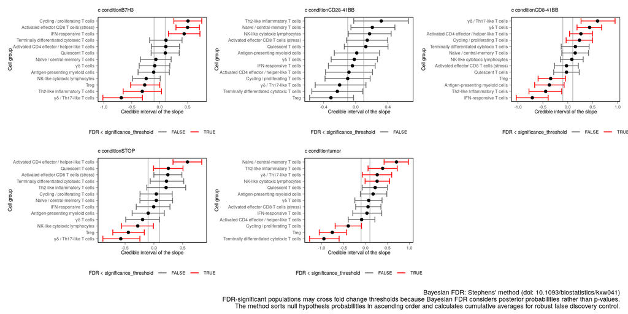

```r
sccomp_result |>
  plot_1D_intervals(significance_statistic = c("FDR"))
```

```r
ggsave(
  file.path(plot_dir, paste0(analysis_label, "_composition_sccomp_41BBL_baseline.pdf")),
  width = 14,
  height = 6,
  device = cairo_pdf
)
```

## tumor is set as the reference condition

This block repeats sccomp with tumor as the reference condition so treatment effects can be read directly as each condition relative to tumor.

```r
sccomp_tumor_reference <- run_sccomp_composition(
  obj = obj,
  cell_group_col = cell_group_col,
  condition_levels = condition_levels_tumor_reference,
  analysis_label = analysis_label,
  output_suffix = "tumor_baseline",
  reference_label = "tumor-reference",
  results_dir = results_dir
)
```

```
## Reference condition for tumor-reference sccomp: tumor
## Cell group column used for analysis: tcell_subtype
```

```r
sccomp_input_tumor_reference <- sccomp_tumor_reference$input
sccomp_result_tumor_reference <- sccomp_tumor_reference$result
```

## Plot Tumor Reference sccomp Results

This block saves the tumor-reference sccomp interval plot using FDR as the significance statistic.

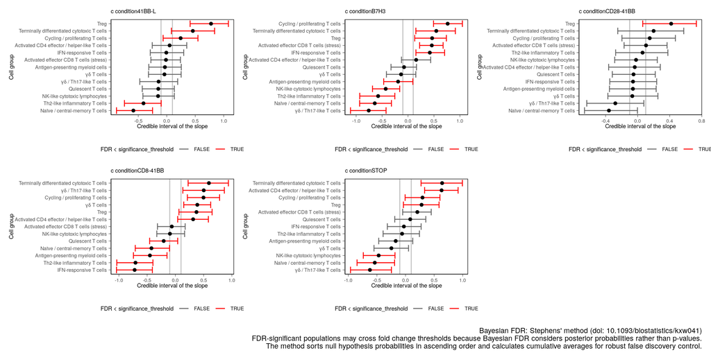

```r
sccomp_result_tumor_reference |>
  plot_1D_intervals(significance_statistic = c("FDR"))
```

```r
ggsave(
  file.path(plot_dir, paste0(analysis_label, "_composition_sccomp_tumor_baseline.pdf")),
  width = 14,
  height = 6,
  device = cairo_pdf
)
```

## STOP is set as the reference condition

This block repeats sccomp with STOP as the reference condition so effects can be read directly as each condition relative to STOP.

```r
sccomp_stop_reference <- run_sccomp_composition(
  obj = obj,
  cell_group_col = cell_group_col,
  condition_levels = condition_levels_stop_reference,
  analysis_label = analysis_label,
  output_suffix = "STOP_baseline",
  reference_label = "STOP-reference",
  results_dir = results_dir
)
```

```
## Reference condition for STOP-reference sccomp: STOP
## Cell group column used for analysis: tcell_subtype
```

```r
sccomp_input_stop_reference <- sccomp_stop_reference$input
sccomp_result_stop_reference <- sccomp_stop_reference$result
```

## Plot STOP Reference sccomp Results

This block saves the STOP-reference sccomp interval plot using FDR as the significance statistic.

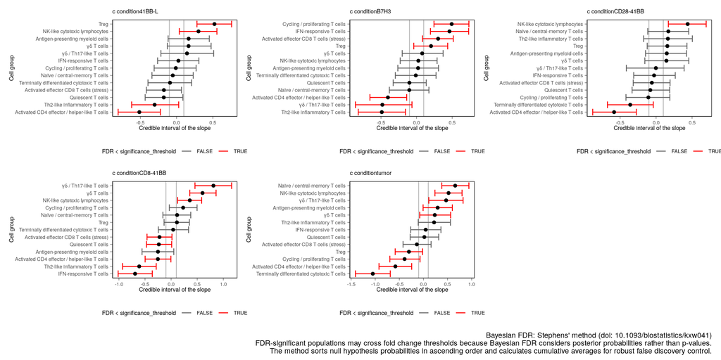

```r
sccomp_result_stop_reference |>
  plot_1D_intervals(significance_statistic = c("FDR"))
```

```r
ggsave(
  file.path(plot_dir, paste0(analysis_label, "_composition_sccomp_STOP_baseline.pdf")),
  width = 14,
  height = 6,
  device = cairo_pdf
)
```